# Assignment 5: Handle Missing Values

*How to do it?*:

- Open the Rmarkdown file of this assignment (link) in Rstudio.
- Right under each **question**, insert a code chunk (you can use the hotkey `Ctrl + Alt + I` to add a code chunk) and code the solution for the question.
- `Knit` the rmarkdown file (hotkey: `Ctrl + Alt + K`) to export an html.
- Publish the html file to your Githiub Page.

*Submission*: Submit the link on Github of the assignment to Canvas.

**The data:**

This assignment works with the Adult Census Data that can be downloaded at [this link.](https://bryantstats.github.io/math421/data/adult_census_missing.csv)

**Questions**

1. Use `read_csv` to import the data. Show the number of NAs for each columns.

```r
library(VIM)
library(tidyverse)
library(dplyr)

df <- read_csv("https://bryantstats.github.io/math421/data/adult_census_missing.csv")
#I commented that line out because it errored the knit
```

[output not shown]

2. Using function `aggr` the VIM package to plot the number of NAs for each column.

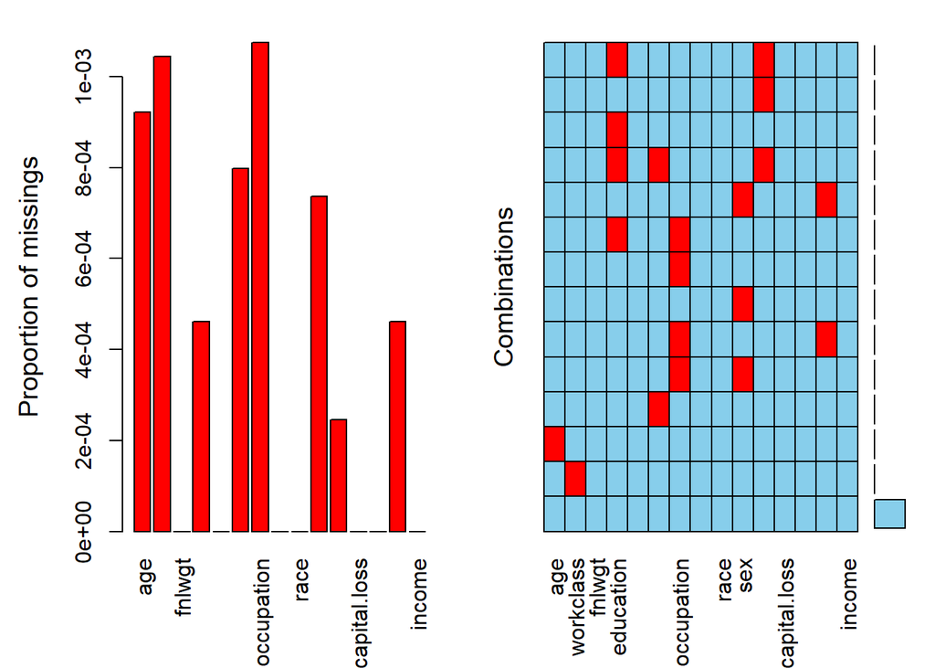

```r
aggr(df)
```

3. Find other forms of missing values. Hint: You can use the `table` function to check if there are suspicious categories (Unknown, for example) in a variable. What all other forms of missing values shown in the data.

```r
table(df$workclass)
```

```
##
##                ?      Federal-gov        Local-gov     Never-worked
##             1835              957             2086                7
##        Not Known          Private     Self-emp-inc Self-emp-not-inc
##               12            22664             1110             2537
##        State-gov          Unknown      Without-pay
##             1293               12               14
```

```r
#? Unknown Not Known
table(df$education)
```

```
##
##         10th         11th         12th      1st-4th      5th-6th      7th-8th
##          931         1174          431          168          333          645
##          9th   Assoc-acdm    Assoc-voc    Bachelors    Doctorate      HS-grad
##          514         1064         1376         5342          413        10475
##      Masters    Not Known    Preschool  Prof-school Some-college      Unknown
##         1719           36           51          575         7273           26
```

```r
#Not Known Unknown
table(df$marital.status)
```

```
##
##              Divorced     Married-AF-spouse    Married-civ-spouse
##                  4435                    23                 14963
## Married-spouse-absent         Never-married             Not Known
##                   418                 10666                    12
##             Separated               Widowed
##                  1025                   993
```

```r
#Not Known
table(df$occupation)
```

```
##
##                 ?      Adm-clerical      Armed-Forces      Craft-repair
##              1840              3761                 9              4090
##   Exec-managerial   Farming-fishing Handlers-cleaners Machine-op-inspct
##              4059               993              1368              2001
##         Not Known     Other-service   Priv-house-serv    Prof-specialty
##                12              3287               149              4132
##   Protective-serv             Sales      Tech-support  Transport-moving
##               647              3647               924              1594
##           Unknown
##                13
```

```r
#? Not Known Unknown
table(df$relationship)
```

```
##
##        Husband  Not-in-family      Not Known Other-relative      Own-child
##          13164           8287             48            979           5054
##        Unknown      Unmarried           Wife
##             26           3439           1564
```

```r
#Not Known Unknown
table(df$race)
```

```
##
## Amer-Indian-Eskimo Asian-Pac-Islander              Black              Other
##                311               1039               3124                271
##              White
##              27816
```

```r
table(df$native.country)
```

```
##
##                          ?                   Cambodia
##                        582                         19
##                     Canada                      China
##                        121                         75
##                   Columbia                       Cuba
##                         59                         95
##         Dominican-Republic                    Ecuador
##                         70                         27
##                El-Salvador                    England
##                        106                         90
##                     France                    Germany
##                         29                        136
##                     Greece                  Guatemala
##                         29                         64
##                      Haiti         Holand-Netherlands
##                         44                          1
##                   Honduras                       Hong
##                         13                         20
##                    Hungary                      India
##                         13                        100
##                       Iran                    Ireland
##                         43                         24
##                      Italy                    Jamaica
##                         73                         81
##                      Japan                       Laos
##                         62                         18
##                     Mexico                  Nicaragua
##                        642                         34
##                  Not Known Outlying-US(Guam-USVI-etc)
##                         24                         14
##                       Peru                Philippines
##                         31                        198
##                     Poland                   Portugal
##                         60                         37
##                Puerto-Rico                   Scotland
##                        114                         12
##                      South                     Taiwan
##                         80                         51
##                   Thailand            Trinadad&Tobago
##                         18                         18
##              United-States                    Unknown
##                      29110                         26
##                    Vietnam                 Yugoslavia
##                         67                         16
```

```r
#? Not Known Unknown
```

4. Replace all the forms of missing values found to NA

```r
df1 <- df %>%
  na_if('Unknown') %>%
  na_if('Missing') %>%
  na_if('Not Available') %>%
  na_if('?') %>%
  na_if('Not Known')
```

5. Replot the number of NAs for each column.

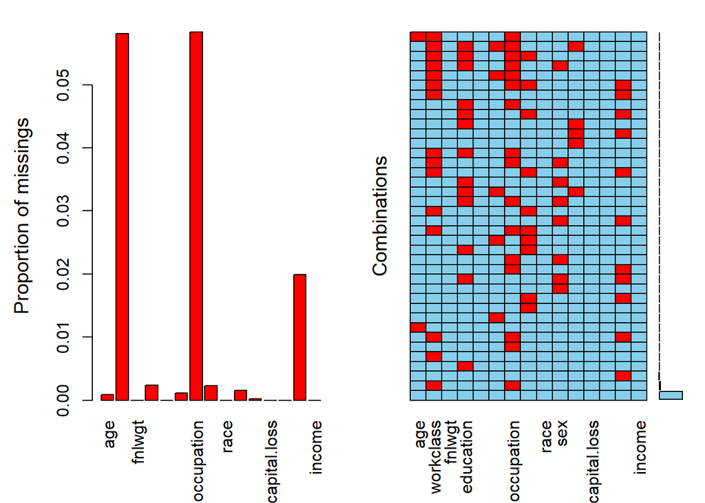

```r
aggr(df1)
```

6. Approach 1 to handle NAs: remove all rows that have any NAs. Save the dataset after removing as a different data. The original data is unchanged (still have NAs). How many rows left after removing?

```r
df2 = drop_na(df1)
count(df2)
```

```
## # A tibble: 1 × 1
##       n
##   <int>
## 1 29865
```

7. Approach 2 to handle NAs: Fill all the NAs with the previous or next value. (Hint: Using `fill` function). Save the dataset after filling as a different data. The original data is unchanged (still have NAs).

```r
dd1 <- df1 %>%
  fill(age, workclass, fnlwgt, education, education.num, marital.status, occupation, relationship, race, sex, capital.gain, capital.loss, hours.per.week, native.country, income, .direction = 'updown')
head(dd1)
```

```
## # A tibble: 6 × 15
##     age workclass fnlwgt education   educa…¹ marit…² occup…³ relat…⁴ race  sex
##   <dbl> <chr>      <dbl> <chr>         <dbl> <chr>   <chr>   <chr>   <chr> <chr>
## 1    90 Private    77053 HS-grad           9 Widowed Exec-m… Not-in… White Fema…
## 2    82 Private   132870 HS-grad           9 Widowed Exec-m… Not-in… White Fema…
## 3    66 Private   186061 Some-colle…      10 Widowed Machin… Unmarr… Black Fema…
## 4    54 Private   140359 7th-8th           4 Divorc… Machin… Unmarr… White Fema…
## 5    41 Private   264663 Some-colle…      10 Separa… Prof-s… Own-ch… White Fema…
## 6    34 Private   216864 HS-grad           9 Divorc… Other-… Unmarr… White Fema…
## # … with 5 more variables: capital.gain <dbl>, capital.loss <dbl>,
## #   hours.per.week <dbl>, native.country <chr>, income <chr>, and abbreviated
## #   variable names ¹education.num, ²marital.status, ³occupation, ⁴relationship
```

8. Approach 3 to handle NAs: For numeric variable, replace the NAs by the median. For categorical variables, replace the NAs to the majority.

```r
calc_mode <- function(x){
  distinct_values <- unique(x)
  distinct_tabulate <- tabulate(match(x, distinct_values))
  distinct_values[which.max(distinct_tabulate)]
}
# I found this code to take mode with a calegorical variable
dd2 <- df1 %>%
  mutate(age = ifelse(is.na(age), median(age), age)) %>%
  mutate(fnlwgt = ifelse(is.na(fnlwgt), median(fnlwgt), fnlwgt)) %>%
  mutate(education.num = ifelse(is.na(education.num), median(education.num), education.num)) %>%
  mutate(capital.gain = ifelse(is.na(capital.gain), median(capital.gain), capital.gain)) %>%
  mutate(capital.loss = ifelse(is.na(capital.loss), median(capital.loss), capital.loss)) %>%
  mutate(hours.per.week = ifelse(is.na(hours.per.week), median(hours.per.week), hours.per.week)) %>%
  mutate(workclass = if_else(is.na(workclass), calc_mode(workclass),workclass)) %>%
  mutate(education = if_else(is.na(education), calc_mode(education),education)) %>%
  mutate(marital.status = if_else(is.na(marital.status), calc_mode(marital.status), marital.status)) %>%
  mutate(occupation = if_else(is.na(occupation), calc_mode(occupation),occupation)) %>%
  mutate(relationship = if_else(is.na(relationship), calc_mode(relationship), relationship)) %>%
  mutate(race = if_else(is.na(race), calc_mode(race),race)) %>%
  mutate(sex = if_else(is.na(sex), calc_mode(sex),sex)) %>%
  mutate(native.country = if_else(is.na(native.country), calc_mode(native.country), native.country)) %>%
  mutate(income = if_else(is.na(income), calc_mode(income),income))
head(dd2)
```

```
## # A tibble: 6 × 15
##     age workclass fnlwgt education   educa…¹ marit…² occup…³ relat…⁴ race  sex
##   <dbl> <chr>      <dbl> <chr>         <dbl> <chr>   <chr>   <chr>   <chr> <chr>
## 1    90 Private    77053 HS-grad           9 Widowed Prof-s… Not-in… White Fema…
## 2    82 Private   132870 HS-grad           9 Widowed Exec-m… Not-in… White Fema…
## 3    66 Private   186061 Some-colle…      10 Widowed Prof-s… Unmarr… Black Fema…
## 4    54 Private   140359 7th-8th           4 Divorc… Machin… Unmarr… White Fema…
## 5    41 Private   264663 Some-colle…      10 Separa… Prof-s… Own-ch… White Fema…
## 6    34 Private   216864 HS-grad           9 Divorc… Other-… Unmarr… White Fema…
## # … with 5 more variables: capital.gain <dbl>, capital.loss <dbl>,
## #   hours.per.week <dbl>, native.country <chr>, income <chr>, and abbreviated
## #   variable names ¹education.num, ²marital.status, ³occupation, ⁴relationship
```